# Mental Health and Lifestyle Analysis Report

Wenduan Wang

2025-11-20

1. Data Preparation and Cleaning 1.1 Execute Data Preparation Script This step runs src/01_prep_data.R, which loads the raw data, renames columns, and saves the cleaned data as processed_data.rds for subsequent scripts.
2. Descriptive Statistical Analysis 2.1 Execute Table Data Generation Script This step runs src/02_create_table.R. It reads the processed data and creates three data frame objects: num_summary, stress_dist, and mental_dist.

2.2 Results Display: Summary Tables Summary Statistics of Numeric Variables

Table 1: Summary Statistics of Numeric Variables (Age, Sleep, Work Hours)

| Mean_Age | SD_Age | Mean_Sleep | SD_Sleep | Mean_WorkHrs | SD_WorkHrs |
| --- | --- | --- | --- | --- | --- |
| 41.23 | 13.43 | 6.48 | 1.5 | 39.47 | 11.45 |

Stress Level Distribution

Table 2: Distribution of Reported Stress Levels

| Stress Level | Count (n) | Percentage (%) |
| --- | --- | --- |
| High | 1002 | 33.4 |
| Low | 1008 | 33.6 |
| Moderate | 990 | 33.0 |

Mental Health Condition Distribution

Table 3: Distribution of Reported Mental Health Conditions

| Mental Health Condition | Count (n) | Percentage (%) |
| --- | --- | --- |
| Anxiety | 628 | 20.9 |
| Bipolar | 573 | 19.1 |
| Depression | 580 | 19.3 |
| None | 595 | 19.8 |
| PTSD | 624 | 20.8 |

3. Data Visualization 3.1 Execute Figure Generation Script This step runs src/03_create_figure.R, which creates and saves the plot files (figure_1_gender.png, etc.) to the output/ folder.

3.2 Results Display: Figures The plots were generated and saved by the external script (03_create_figure.R). We use include_graphics to embed them here. Figure 1: Gender Distribution

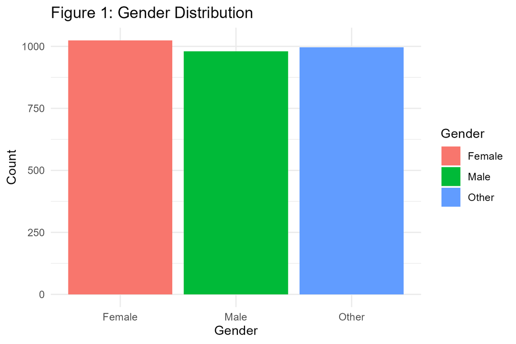

Figure 2: Age Distribution

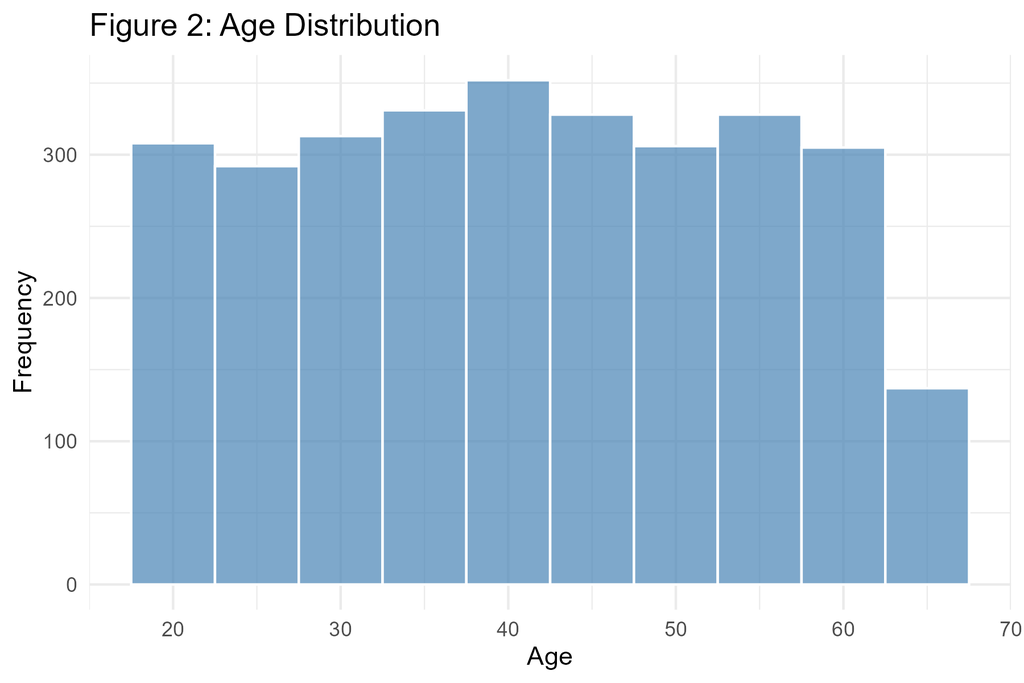

Figure 3: Diet Type Distribution

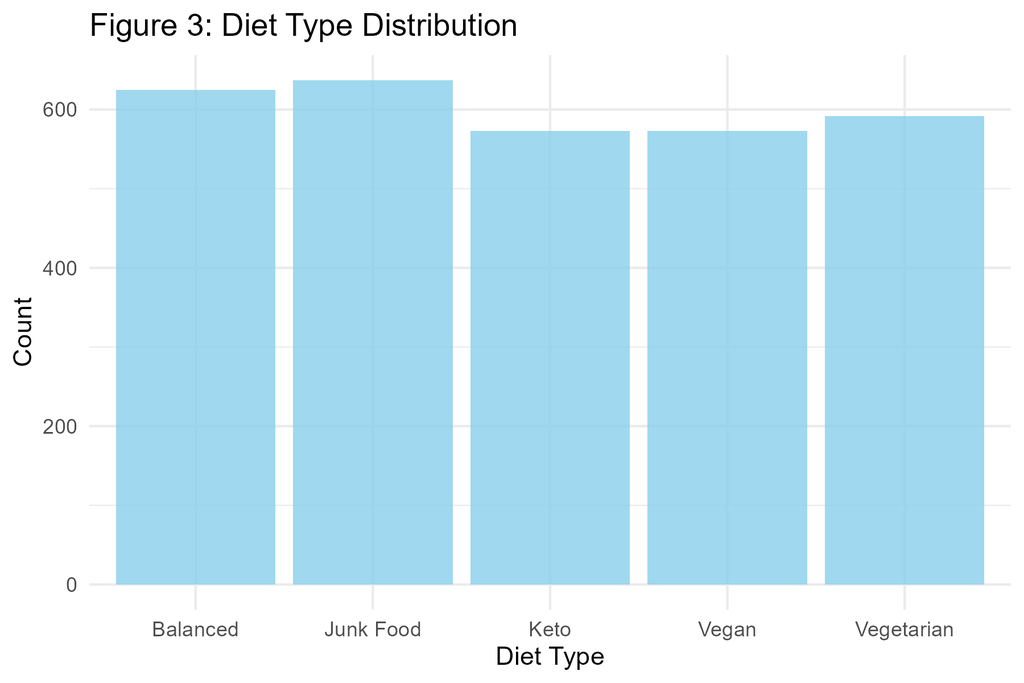